# Reproducible Analyses with knitr and rmarkdown

April 1, 2015

## Introduction

## Reproducibility

[figure not shown]

## At the lab?

[figure not shown]

## Where do we fit in?

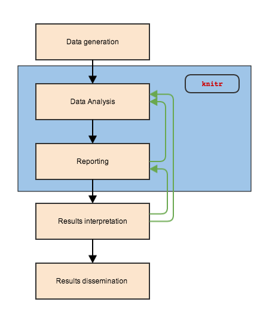

## Data analysis

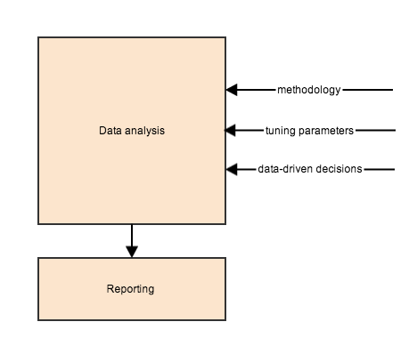

Goal: code + prose = report

## Solution

- Cut and paste for report production is not a viable method
  - tedious
  - slow
  - error-prone
- Incorporate analysis code into text documents
  - `knit` to create results
  - results get incorporated into document
  - post-process to get any type of output format
- Literate documents
  - R Code creates results to inform report
  - Prose surrounding code informs analysis

## How? Markdown.

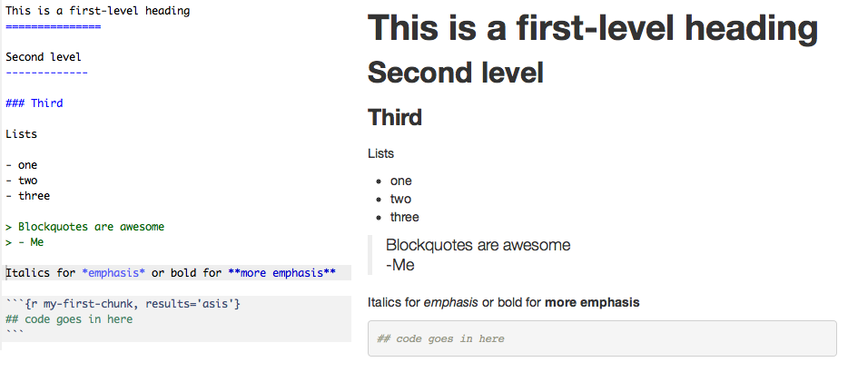

## Contrast with html

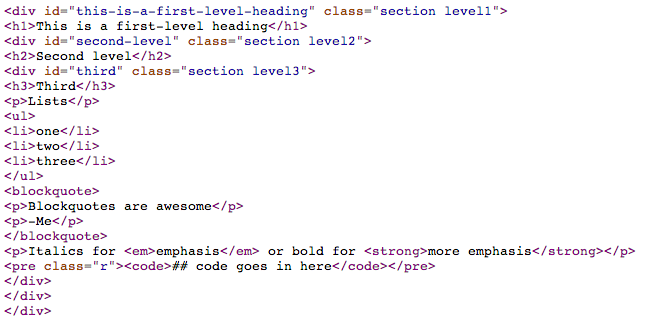

## … and tex

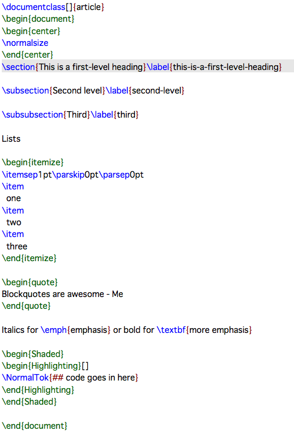

## Incorporating code chunks

Three backticks, each chunk needs a unique name:

````
```{r my-first-chunk}
## code goes in here and gets evaluated
t.test(mpg ~ vs, data = mtcars)
```
````

```
##
##  Welch Two Sample t-test
##
## data:  mpg by vs
## t = -4.6671, df = 22.716, p-value = 0.0001098
## alternative hypothesis: true difference in means is not equal to 0
## 95 percent confidence interval:
##  -11.462508  -4.418445
## sample estimates:
## mean in group 0 mean in group 1
##        16.61667        24.55714
```

## Inline code

Inline code uses single backticks

The mean mpg is `` `r round(mean(mtcars$mpg), 2)` ``.

The mean mpg is 20.09.

## Try it

- Open Rstudio
- Click New > Rmarkdown
- Select output format

#### Examine the markdown prose and the code.

#### What do you expect the output to look like?

- Click `knit`
- What do you get?

## How it works: knitr

Code chunks are evaluated sequentially the same, fresh R session:

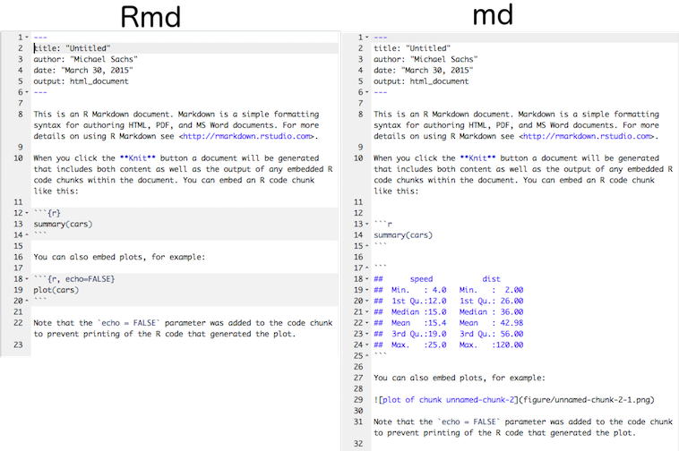

## How it works: pandoc

- Pandoc converts the markdown format to some other document type:
  - Word
  - Html
  - Pdf
  - …
- Templates and output formats for specific uses:
  - Beamer slideshows
  - ioslides presentations
  - Tufte-style handouts

**Note: pdf based formats require Latex. Ask your IT person to install it**

## Caveats

- Markdown is minimalistic
- Easy to write and read

rmarkdown + knitr is designed to *quickly* and *simply* generate analytic reports with minimal markup

- Not complex or precise enough for **complete** control over output
- How much precision do you need?

## Markdown specs

- Paragraphs, `# headers, ## subheader, etc`, `> blockquotes`
- Emphasis, `_italics_, *italics*, __bold__, **bold**`
- Images/links: `![name](pathtoimage)`, `[text](link)`
- Lists/ordered lists
- Code chunks
- Latex equations: `$\sum_{i=1}^nX_i/n$` = \(\sum_{i=1}^nX_i/n\)
- Tables
- Citations: `[@citekey]`, bibtex, endnote, others supported

## Front matter

- Metadata
- Document types
- Other options
  - Default figure size, table of contents, theme
  - See http://rmarkdown.rstudio.com/ for complete documentation

```
---
title: "Reproducible Analyses with knitr and rmarkdown"
author: "Michael Sachs"
date: "March 31, 2015"
output:
  ioslides_presentation:
    widescreen: true
---
```

## Controlling R output

## knitr chunk output

### Results

Default: `results = 'markup'`

````
```{r markup, results = 'markup'}
head(mtcars, 4)
```
````

```
##                 mpg cyl disp  hp drat    wt  qsec vs am gear carb
## Mazda RX4      21.0   6  160 110 3.90 2.620 16.46  0  1    4    4
## Mazda RX4 Wag  21.0   6  160 110 3.90 2.875 17.02  0  1    4    4
## Datsun 710     22.8   4  108  93 3.85 2.320 18.61  1  1    4    1
## Hornet 4 Drive 21.4   6  258 110 3.08 3.215 19.44  1  0    3    1
```

## knitr chunk output

`results = 'asis'`

````
```{r asis, results = 'asis'}
head(mtcars, 4)
```
            mpg cyl disp  hp drat    wt  qsec vs am gear carb
````

Mazda RX4 21.0 6 160 110 3.90 2.620 16.46 0 1 4 4 Mazda RX4 Wag 21.0 6 160 110 3.90 2.875 17.02 0 1 4 4 Datsun 710 22.8 4 108 93 3.85 2.320 18.61 1 1 4 1 Hornet 4 Drive 21.4 6 258 110 3.08 3.215 19.44 1 0 3 1

## knitr chunk output

### Make tables pretty with `knitr::kable` and `results = 'asis'`

```r
kable(head(mtcars, 4), digits = 1, caption = "Motor Trend Cars, 1974")
```

Motor Trend Cars, 1974

|  | mpg | cyl | disp | hp | drat | wt | qsec | vs | am | gear | carb |
| --- | --- | --- | --- | --- | --- | --- | --- | --- | --- | --- | --- |
| Mazda RX4 | 21.0 | 6 | 160 | 110 | 3.9 | 2.6 | 16.5 | 0 | 1 | 4 | 4 |
| Mazda RX4 Wag | 21.0 | 6 | 160 | 110 | 3.9 | 2.9 | 17.0 | 0 | 1 | 4 | 4 |
| Datsun 710 | 22.8 | 4 | 108 | 93 | 3.8 | 2.3 | 18.6 | 1 | 1 | 4 | 1 |
| Hornet 4 Drive | 21.4 | 6 | 258 | 110 | 3.1 | 3.2 | 19.4 | 1 | 0 | 3 | 1 |

## Tables and other output

Several other packages are available to customize table output:

- `pander`: Good for printing output from regression models:

```r
pander::pander(lm(mpg ~ factor(cyl), data = mtcars))
```

Fitting linear model: mpg ~ factor(cyl)

|  | Estimate | Std. Error | t value | Pr(>\|t\|) |
| --- | --- | --- | --- | --- |
| **factor(cyl)6** | -6.921 | 1.558 | -4.441 | 0.0001195 |
| **factor(cyl)8** | -11.56 | 1.299 | -8.905 | 8.568e-10 |
| **(Intercept)** | 26.66 | 0.9718 | 27.44 | 2.688e-22 |

- `xtable`: endless customization to tables
- `stargazer`: nice looking tables for multiple regression models

## Figure options

The important ones:

- `fig.width`, `fig.height`, in inches. Can also be set globally in the header.
- `fig.align`, left, right or center
- `fig.cap = "Caption"` add caption to figure

## Example figure

````
```{r ggmt, fig.align = 'center', fig.height = 3.5, fig.width = 6.5}
library(ggplot2)
ggplot(mtcars, aes(x = disp, y = mpg, size = wt)) +
  geom_point() + geom_smooth(method = "loess")
```
````

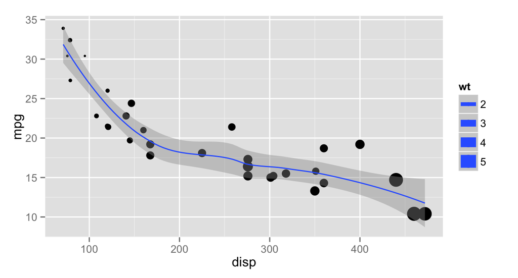

## Example figure

````
```{r basemt, fig.align = 'center', fig.height = 3.5, fig.width = 6.5}
with(mtcars, hist(mpg))
```
````

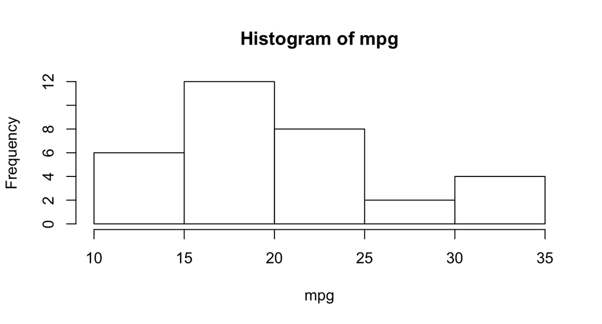

## Try it!

- Create a new rmarkdown document with an output format of your choice
- Use the `BMI.CSV` dataset to perform some basic analysis
- Display the data using `head`
- Summarize the data
- Do a t-test
- Make a figure using ggplot
- Make a table of regression coefficients
- *Write about what you are doing along the way*

## Summary

- Analysis + report writing should be easy and integrated
- knitr + rmarkdown + pandoc all in Rstudio
- You don't have to remember everything, use the menus and help documents
- Your future self will thank you for having a reproducible analysis

## Resources

| Topic | Link |
| --- | --- |
| KBroman's UWisc Class | https://kbroman.github.io/knitr_knutshell |
| Knitr homepage | http://yihui.name/knitr/ |
| rmarkdown documentation | http://rmarkdown.rstudio.com/ |
| Another knitr tutorial | http://sachsmc.github.io/knit-git-markr-guide |
| Pandoc reference | http://johnmacfarlane.net/pandoc/ |